# Scrapping and analyzing 400.000 articles

Manos Antoniou

2018-04-05

In this post i will analyze the articles published by [NEWSBEAST](http://www.newsbeast.gr), one of the main on-line publishers in Greece. The main question is **“Are there any trends on the daily posting frequency of NEWSBEAST?”** The steps below were followed before the main data analysis (link for the full r code can be found at the end of the article):

- Scrapping the articles from the site (www.newbeast.gr) using rvest & car libraries in R
- Data preparation (including data cleansing, transformation)
- Exploratory analysis

# MAIN DATA ANALYSIS

Let’s create a scatter plot to see the number of articles published per day for the last 4 years.

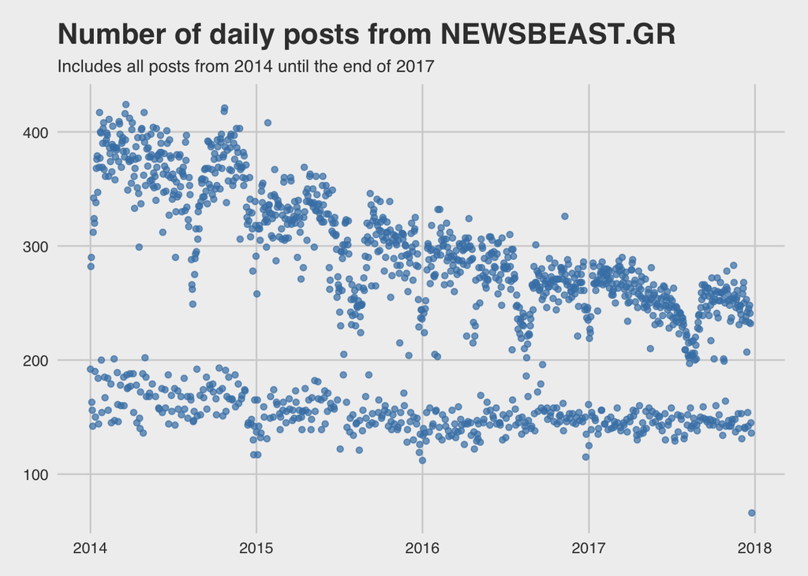

We can spot clearly that there is a constant trend (during the last 4 years) of two different patterns on number of daily articles published. We suspect that on specific weekdays (maybe weekends?) there are significantly less published daily articles.  
A second trend (not so clear) could be that each consecutive year less articles are published.

Now let’s plot it again by distinguish each week day with a different color for a more clear view.

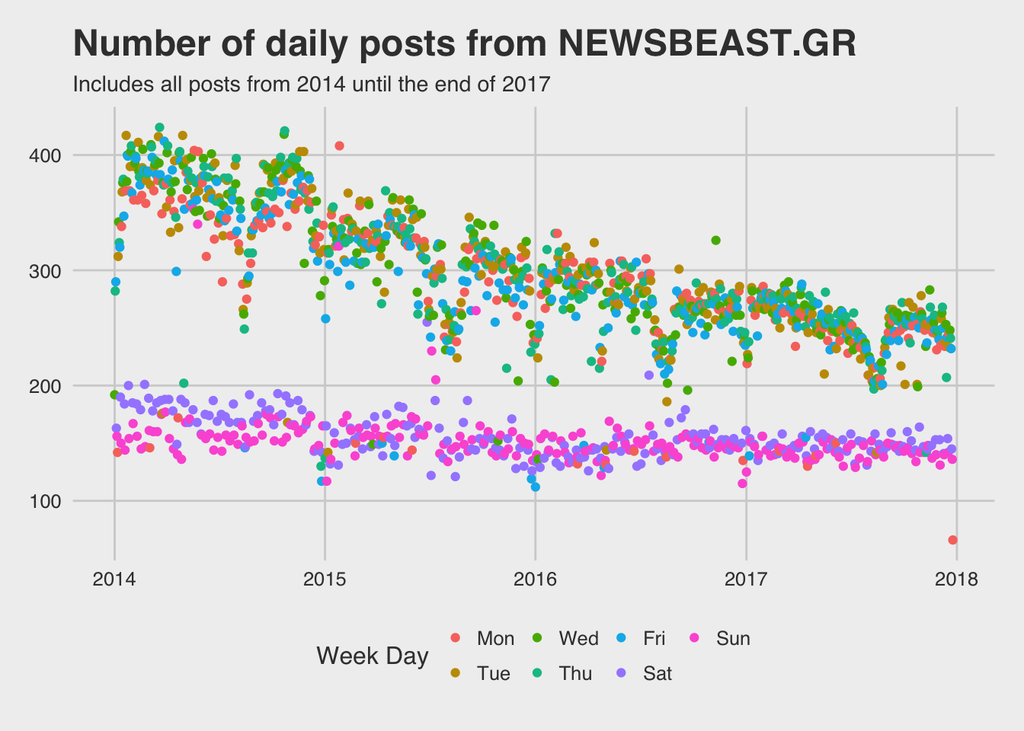

So now it is clear that during the weekends the number of daily posts are much lower than on work-week days.

# MODELLING

Now let’s try to fit a model on each week day and create a plot to present these. In the plot below each weekday is presented by by fitting a separate smooth line using [LOESS regression](https://en.wikipedia.org/wiki/Local_regression)

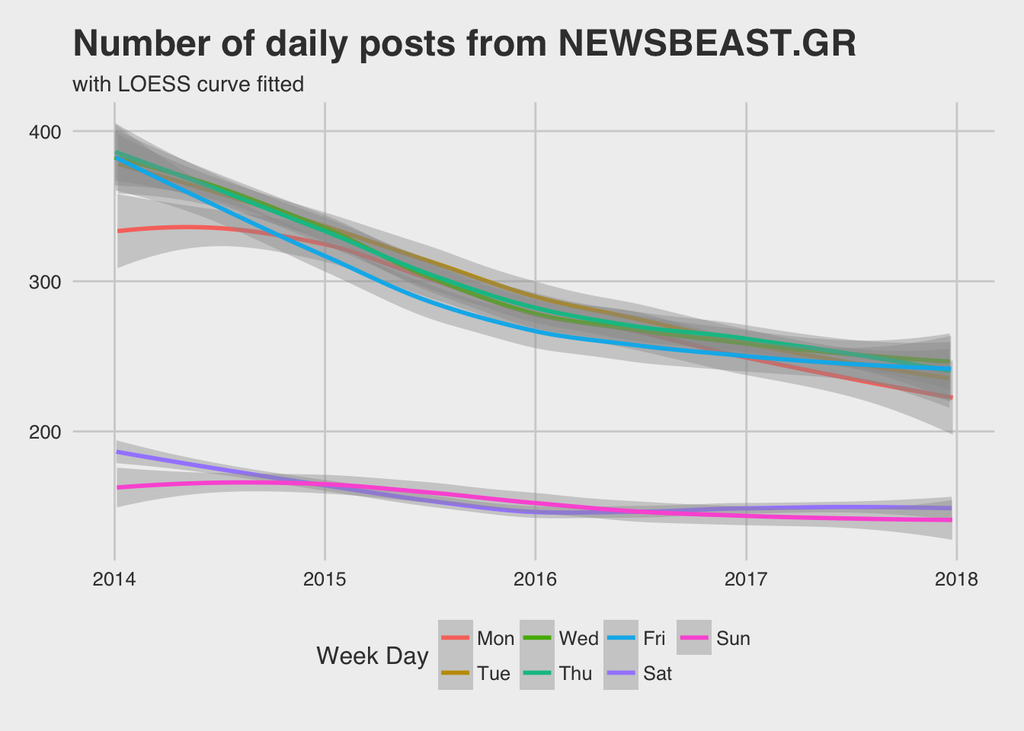

The standard error for weekend days (95% confidence level) indicates that the difference from the work-week days is significant.

Now let’s investigate if there are significant differences between different years.

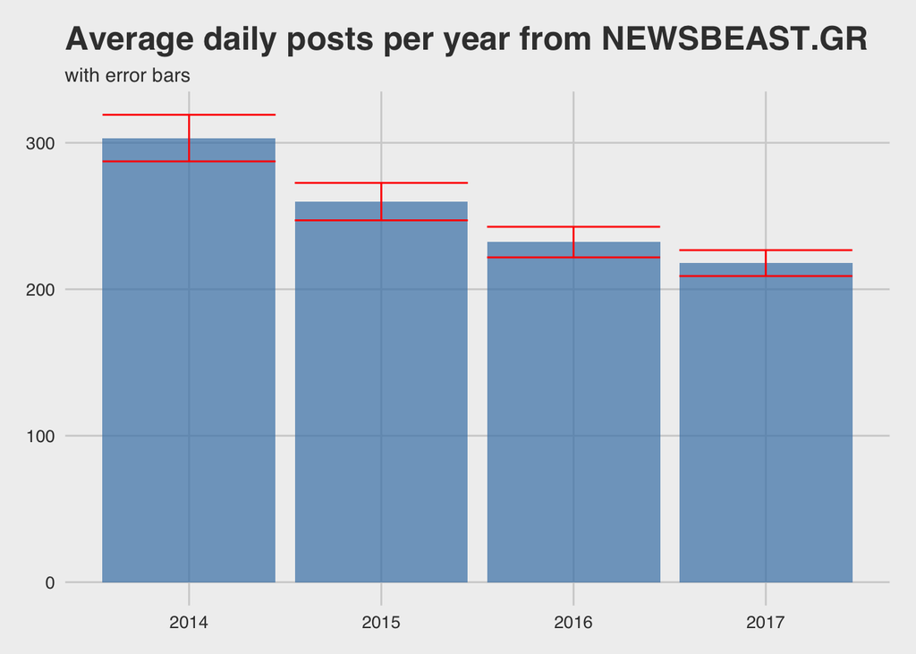

This finding can be confirmed by applying the non-parametric [Wilcoxon signed-rank](https://en.wikipedia.org/wiki/Wilcoxon_signed-rank_test) test in different samples (table below)

| Wilcoxon test between Years | p-value |
| --- | --- |
| 2014 - 2015 | < 0.001 |
| 2015 - 2016 | < 0.001 |
| 2016 - 2017 | < 0.001 |

All p-values are very low (<0.01) with confidence level of 0.95, so the difference in daily mean articles posted is significant.

# TIME SERIES ANALYSIS

Finally in order to investigate other, less obvious seasonal trends, we used a package dedicated on time series analysis. Using the prophet package for R a forecasting model was fitted, as can be seen below, which revealed more seasonal trends. In particular two major “drops” appear in daily articles around the **christmas period** and the **summer holidays** (around August). There is also a minor “drop” around the **Easter period**.

```
## Initial log joint probability = -86.749
## Optimization terminated normally:
##   Convergence detected: relative gradient magnitude is below tolerance
```

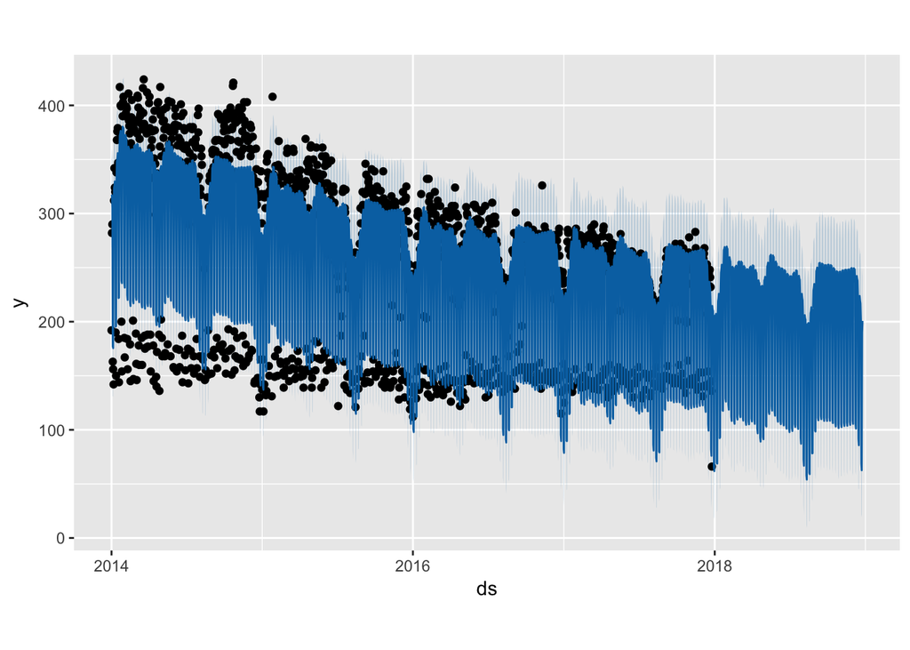

The other useful feature is the ability to plot the various components (plot below) It is a simple way to pull out the daily/weekly/yearly trends. In particular in the chart below we can easily spot the drop on the weekends, the “drops” in daily articles around the **christmas period**, **summer holidays**, **Easter period** and the yearly “drop”.

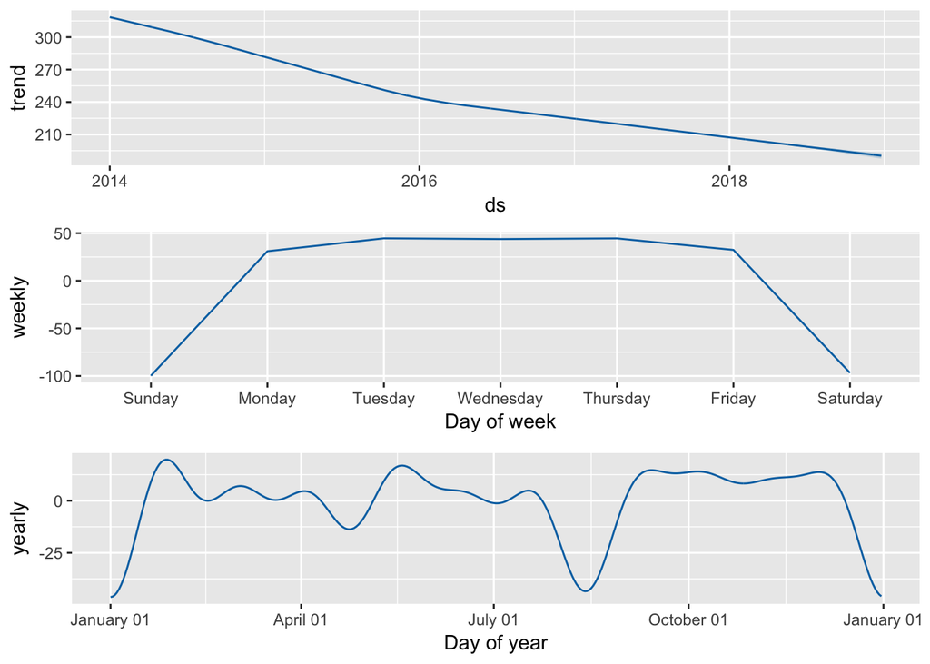

```r
prophet_plot_components(m, forecast)
```

# CONCLUSIONS

There are various outcomes from this analysis on Newsbeast.gr. In particular:

- During the last 4 years there is a significant decrease on daily posted articles. Overall around **30%** less articles.
- The published articles during the weekends are much less than on weekdays.
- There are 2 major “drops” in daily articles each year, during the Christmas & summer holidays.
- There is a minor “drop” in daily articles published each year during the Easter holidays

[Full R code](https://github.com/mantoniou/blogdown/blob/master/content/post/2018-03-13-scrapping-and-analyzing-400-000-articles-from-newsbeast-gr.Rmd)